# COMPSCIX 415.2 Homework 8

Lionel Armstrong

March 24, 2018

```r
library(mdsr)
library(tidyverse)
library(broom)
library(dbplyr)
library(ggplot2)
library(rpart)
library(partykit)
library(ROCR)
library(plyr)
library(dplyr)
```

# Exercise 1

*Load the train.csv dataset into R. How many observations and columns are there? Convert the target variable to a factor because it will be loaded into R as an integer by default.*

```r
train_data <- read_csv('C:/Rdata/train_titanic.csv')

# Change Survived to factor
train_data <- train_data %>% mutate(Survived = as.factor(Survived) )
```

# Exercise 2

*Our first step is to randomly split the data into train and test datasets. We will use a 70/30 split, and use the random seed of 29283 so that we all should get the same training and test set.*

```r
set.seed(29283)
# Create train_set
train_set <- train_data %>%sample_frac(.70,replace = FALSE)

#Create test_set
test_set <- train_data %>% filter(!(PassengerId%in% train_set$PassengerId))
```

# Exercise 3

*Our target is called Survived. First, fit a logistic regression model using Pclass, Sex, Fare as your three features. Fit the model using the glm() function.*

*Ask yourself these questions before fitting the model:*

*.What kind of relationship will these features have with the probability of survival?*

*.Are these good features, given the problem we are trying to solve?*

```r
#Create logistic regression model
mod_3 <- glm(Survived ~ Pclass + Sex + Fare, data = train_data, family = 'binomial')

#Show model results
tidy(mod_3)
```

```
##          term     estimate   std.error   statistic      p.value
## 1 (Intercept)  3.143731168 0.363645175   8.6450512 5.378116e-18
## 2      Pclass -0.917173290 0.121938328  -7.5216161 5.410325e-14
## 3     Sexmale -2.630648930 0.184639367 -14.2474976 4.646346e-46
## 4        Fare  0.001450226 0.002030183   0.7143326 4.750215e-01
```

*After fitting the model, output the coefficients using the broom package and answer these questions:*

*.How would you interpret the coefficients?* *.Are the features significant?*

Use the code below and fill in the blanks. library(broom)

##### ANSWER

The Sex variable coefficient indicates a probability of survial was base on sex.The p-value of the Sex variable is significant to survial.Pclass is less significance and Fare has even less significance.

```r
# Fit a model with intercept only

mod_0 <- glm(Survived ~ 1, data = train_data, family = 'binomial')

# take a look at the features and coefficients

tidy(mod_0)
```

```
##          term   estimate  std.error statistic      p.value
## 1 (Intercept) -0.4732877 0.06888737 -6.870457 6.399672e-12
```

# Exercise 4

*Now, let’s fit a model using a classification tree, using the same features and plot the final decision tree. Use the code below for help.*

*Answer these questions:*

*.Describe in words one path a Titanic passenger might take down the tree. (Hint: look at your tree, choose a path from the top to a terminal node, and describe the path like this - a male passenger who paid a fare > 30 and was in first class has a high probability of survival)*

*.Does anything surprise you about the fitted tree?*

```r
tree_mod <- rpart(Survived ~ Pclass + Sex + Fare, data = train_data)
summary(tree_mod)
```

```
## Call:
## rpart(formula = Survived ~ Pclass + Sex + Fare, data = train_data)
##   n= 891
##
##           CP nsplit rel error    xerror       xstd
## 1 0.44444444      0 1.0000000 1.0000000 0.04244576
## 2 0.03070175      1 0.5555556 0.5555556 0.03574957
## 3 0.01315789      3 0.4941520 0.5029240 0.03444798
## 4 0.01169591      5 0.4678363 0.5116959 0.03467453
## 5 0.01000000      7 0.4444444 0.5058480 0.03452394
##
## Variable importance
##    Sex   Fare Pclass
##     60     25     15
##
## Node number 1: 891 observations,    complexity param=0.4444444
##   predicted class=0  expected loss=0.3838384  P(node) =1
##     class counts:   549   342
##    probabilities: 0.616 0.384
##   left son=2 (577 obs) right son=3 (314 obs)
##   Primary splits:
##       Sex    splits as  RL,           improve=124.42630, (0 missing)
##       Pclass < 2.5      to the right, improve= 43.78183, (0 missing)
##       Fare   < 10.48125 to the left,  improve= 37.94194, (0 missing)
##   Surrogate splits:
##       Fare < 77.6229  to the left,  agree=0.679, adj=0.089, (0 split)
##
## Node number 2: 577 observations
##   predicted class=0  expected loss=0.1889081  P(node) =0.647587
##     class counts:   468   109
##    probabilities: 0.811 0.189
##
## Node number 3: 314 observations,    complexity param=0.03070175
##   predicted class=1  expected loss=0.2579618  P(node) =0.352413
##     class counts:    81   233
##    probabilities: 0.258 0.742
##   left son=6 (144 obs) right son=7 (170 obs)
##   Primary splits:
##       Pclass < 2.5      to the right, improve=31.16313, (0 missing)
##       Fare   < 48.2     to the left,  improve=10.11421, (0 missing)
```

[output cut: 62 more lines]

```
##     class counts:    17    16
##    probabilities: 0.515 0.485
##   left son=210 (25 obs) right son=211 (8 obs)
##   Primary splits:
##       Fare < 10.825   to the left,  improve=5.604848, (0 missing)
##
## Node number 210: 25 observations
##   predicted class=0  expected loss=0.32  P(node) =0.02805836
##     class counts:    17     8
##    probabilities: 0.680 0.320
##
## Node number 211: 8 observations
##   predicted class=1  expected loss=0  P(node) =0.008978676
##     class counts:     0     8
##    probabilities: 0.000 1.000
```

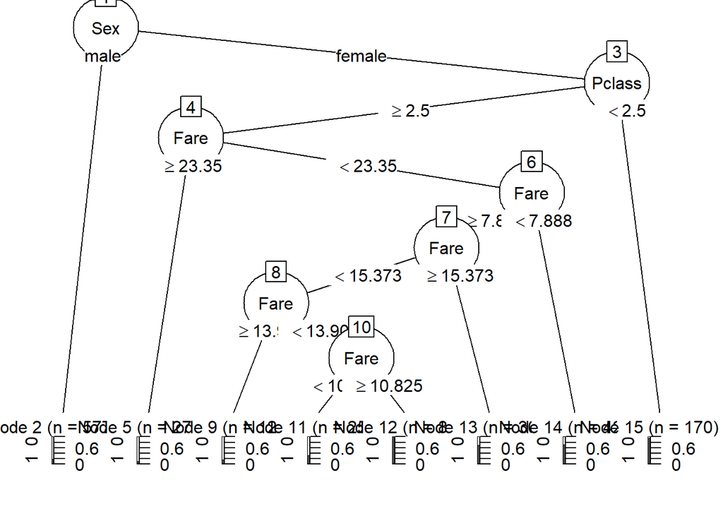

```r
plot(as.party(tree_mod))
```

#### Exercise 5

*Evaluate both the logistic regression model and classification tree on the test_set. First, use the predict() function to get the model predictions for the testing set. Use the code below for help.*

*It may seem odd that we are using the same predict() function to make predictions for two completely different types of models (logistic regression and classification tree). This is a feature of R that there are many generic functions that you can apply to different R objects. Depending on the class of the object that is passed to the generic function, R will know which definition of the generic function to use on that object.*

```r
test_logit <- predict(mod_3, newdata = test_set, type = 'response')
test_tree <- predict(tree_mod, newdata = test_set) [,2]
glimpse(test_logit)
```

```
##  Named num [1:267] 0.0973 0.9113 0.0974 0.9059 0.6031 ...
##  - attr(*, "names")= chr [1:267] "1" "2" "3" "4" ...
```

*(a) Next, we will plot the ROC curves from both models using the code below. Don’t just copy and paste the code. Go through it line by line and see what it is doing. Recall that predictions from your decision tree are given as a two column matrix.*

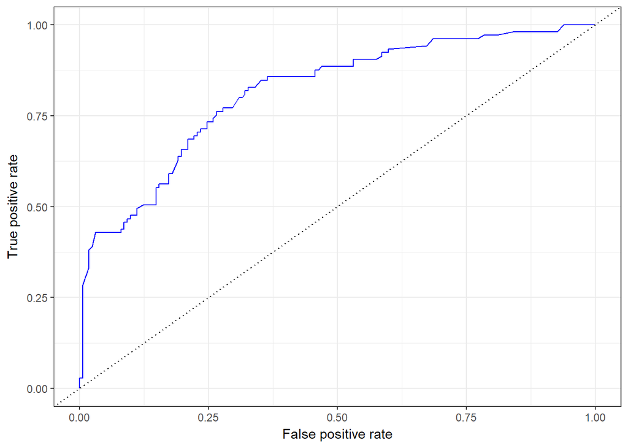

```r
# create the prediction objects for both models
pred_logit <- prediction(predictions = test_logit, labels = test_set$Survived)
pred_tree <- prediction(predictions = test_tree, labels = test_set$Survived)


# get the FPR and TPR for the logistic model
# recall that the ROC curve plots the FPR on the x-axis
perf_logit <- performance(pred_logit, measure = 'tpr', x.measure = 'fpr')
perf_logit_tbl <- tibble(perf_logit@x.values[[1]], perf_logit@y.values[[1]])


# Change the names of the columns of the tibble
names(perf_logit_tbl) <- c('fpr', 'tpr')

# get the FPR and TPR for the tree model
perf_tree <- performance(pred_tree, measure = 'tpr', x.measure = 'fpr')
perf_tree_tbl <- tibble(perf_tree@x.values[[1]], perf_tree@y.values[[1]])

# Change the names of the columns of the tibble
names(perf_tree_tbl) <- c('fpr', 'tpr')

# Plotting function for plotting a nice ROC curve using ggplot

plot_roc <- function(perf_tbl) {
  p <- ggplot(data = perf_tbl, aes(x = fpr, y = tpr)) +
  geom_line(color = 'blue') +
  geom_abline(intercept = 0, slope = 1, lty = 3) +
  labs(x = 'False positive rate', y = 'True positive rate') +
  theme_bw()
  return(p)
}

# Create the ROC curves using the function we created above

plot_roc(perf_logit_tbl)
```

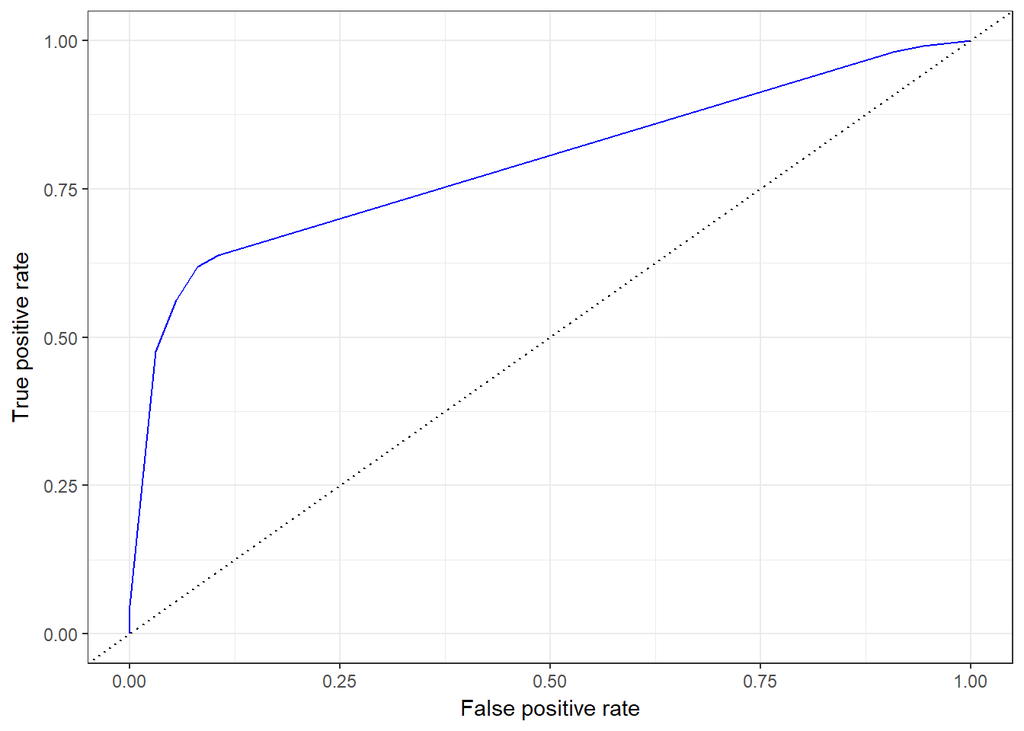

```r
plot_roc(perf_tree_tbl)
```

*b) Now, use the performance() function to calculate the area under the curve (AUC) for both ROC curves. Check ?performance for help on plugging in the right measure argument.

```r
# calculate the AUC
#?performance
auc_logit <- performance(pred_logit, measure = 'auc')
auc_tree <- performance(pred_tree, measure = 'auc')

auc_logit
```

```
## An object of class "performance"
## Slot "x.name":
## [1] "None"
##
## Slot "y.name":
## [1] "Area under the ROC curve"
##
## Slot "alpha.name":
## [1] "none"
##
## Slot "x.values":
## list()
##
## Slot "y.values":
## [[1]]
## [1] 0.8147854
##
##
## Slot "alpha.values":
## list()
```

```r
# extract the AUC value
auc_logit@y.values[[1]]
```

```
## [1] 0.8147854
```

```r
auc_tree@y.values[[1]]
```

```
## [1] 0.7924162
```

*What do you notice about the ROC curves and the AUC values? Are the models performing well?* *Is the logistic regression model doing better, worse, or about the same as the classification tree?*

# ANSWER

Both models perform well as shown by their position towards the upper left corner. The logistic regression model performs best. The rate of climb on the y-axis begins to slow around .25 which be a good cutoff point

*(c) Lastly, pick a probability cutoff by looking at the ROC curves. You pick, there’s no right answer (but there is a wrong answer - make sure to pick something between 0 and 1). Using that probability cutoff, create the confusion matrix for each model by following these steps:*

*1.Pick a cutoff value.*

#### ANSWER

Selected cutoff rate is .25

*2.Append the predicted probability values from each model (you created these at the beginning of Exercise 5) to your test_set tibble using mutate().*

#### ANSWER

```r
test_set <- test_set %>% mutate (tree_prob = test_tree) %>%
  mutate (tree_cat = case_when (tree_prob < .25 ~ 'No',
                                tree_prob >= .25 ~'Yes'))

test_set <- test_set %>% mutate (logit_prob = test_logit) %>%
   mutate (logit_cat = case_when (logit_prob < .25 ~ 'No',
                                  logit_prob >= .25 ~'Yes'))
```

*3.Create a new column for the predicted class from each model using mutate() and case_when(). Your new predicted class columns can have two possible values: yes or no which represents whether or not the passenger is predicted to have survived or not given the predicted probability.*

#### ANSWER

```r
#test_set <- test_set %>% mutate (tree_prob = test_tree) %>%
#  mutate (tree_cat = case_when (tree_prob < .25 ~ 'No',
#                                tree_prob >= .25 ~'Yes'))

#test_set <- test_set %>% mutate (logit_prob = test_logit) %>%
#   mutate (logit_cat = case_when (logit_prob < .25 ~ 'No',
#                                  logit_prob >= .25 ~'Yes'))

#glimpse(test_set)
```

*4.You should now have 4 extra columns added to your test_set tibble, two columns of predicted probabilities, and two columns of the predicted categories based on your probability cutoff.*

# ANSWER:

I couldn’t figure out why the code below threw error object tree_cat not found when the glimpse function shows the object. When I coded test_set$tree_cat the following error is thrown: Error in FUN(X[[i]], …) : object ‘No’ not found. Please show correct code in your comments.

```r
#class(test_set$tree_cat)
#test_set %>% count(test_set$tree_cat, Survived) %>% spread(Survived, n)
#test_set %>% count(logit_cat, Survived) %>% spread(Survived, n)
```